# CF_CueRatio_lmm

```r
summary(rePCA(glmm_resp_etd1))
```

```
## $Participant
## Importance of components:
##                          [,1]   [,2]   [,3]    [,4]    [,5]    [,6]    [,7]      [,8]
## Standard deviation     1.3463 0.6445 0.6092 0.44009 0.32770 0.24962 0.19412 2.881e-05
## Proportion of Variance 0.6042 0.1384 0.1237 0.06456 0.03579 0.02077 0.01256 0.000e+00
## Cumulative Proportion  0.6042 0.7426 0.8663 0.93087 0.96667 0.98744 1.00000 1.000e+00
```

`Intercept` was removed from extended1 model.

```r
file_resp_etd2 <- file.path(folder_lmm, "Resp_lmm_etd2.RData")

# fit the etd2 model
if (!file.exists(file_resp_etd2)) {
  glmm_resp_etd2 <- glmer(
    Resp ~ Cue * Congruency * Alignment * SameDifferent + Probability +
      (0 + Cue_C + Sam_C + # Con_C + Ali_C +
         Cue_Sam + Con_Sam + # Cue_Con + Con_Ali + Ali_Sam + Cue_Ali +
         Cue_Con_Sam + Con_Ali_Sam +# Cue_Con_Ali + Cue_Ali_Sam +
         Cue_Con_Ali_Sam | Participant),
    family = binomial(link = "probit"),
    data = df_lmm,
    control = glmerControl(optimizer = "optimx", # calc.derivs = FALSE,
                           optCtrl = list(method = "nlminb", starttests = FALSE, kkt = FALSE))
  )

  # save(glmm_resp_etd2, file = glmm_resp_etd2)
} else {
  load(file_resp_etd2)
}

print(summary(glmm_resp_etd2), corr = FALSE)
```

```
## Generalized linear mixed model fit by maximum likelihood (Laplace Approximation) ['glmerMod']
##  Family: binomial  ( probit )
## Formula: Resp ~ Cue * Congruency * Alignment * SameDifferent + Probability +      (0 + Cue_C + Sam_C + Cue_Sam + Con_Sam + Cue_Con_Sam + Con_Ali_Sam +          Cue_Con_Ali_Sam | Participant)
##    Data: df_lmm
## Control: glmerControl(optimizer = "optimx", optCtrl = list(method = "nlminb",      starttests = FALSE, kkt = FALSE))
##
##      AIC      BIC   logLik deviance df.resid
##  64871.6  65286.8 -32389.8  64779.6    61391
##
## Scaled residuals:
##     Min      1Q  Median      3Q     Max
## -5.3445 -0.6291  0.2780  0.5980  4.0776
##
## Random effects:
##  Groups      Name            Variance Std.Dev. Corr
##  Participant Cue_C           0.1154   0.3397
##              Sam_C           0.2102   0.4584   -0.20
##              Cue_Sam         0.7150   0.8456    0.08  0.02
##              Con_Sam         0.3213   0.5668   -0.22 -0.19  0.03
##              Cue_Con_Sam     1.1358   1.0657   -0.10  0.02  0.74  0.23
##              Con_Ali_Sam     0.1080   0.3286    0.17  0.30  0.44 -0.47  0.45
##              Cue_Con_Ali_Sam 0.1371   0.3703    0.08 -0.41  0.09 -0.05 -0.51 -0.44
## Number of obs: 61437, groups:  Participant, 64
##
## Fixed effects:
##                                                     Estimate Std. Error z value Pr(>|z|)
## (Intercept)                                         0.123252   0.010709  11.509  < 2e-16 ***
## Cue2-1                                              0.099768   0.044345   2.250 0.024459 *
## Congruency2-1                                      -0.129109   0.011622 -11.109  < 2e-16 ***
## Alignment2-1                                        0.037931   0.011558   3.282 0.001031 **
## SameDifferent2-1                                   -1.314484   0.058587 -22.436  < 2e-16 ***
## Probability0.5                                      0.043315   0.014521   2.983 0.002855 **
## Probability0.75                                     0.028661   0.015913   1.801 0.071684 .
## Cue2-1:Congruency2-1                               -0.013110   0.023309  -0.562 0.573820
## Cue2-1:Alignment2-1                                -0.086384   0.023115  -3.737 0.000186 ***
## Congruency2-1:Alignment2-1                          0.126081   0.023204   5.434 5.53e-08 ***
## Cue2-1:SameDifferent2-1                             0.285404   0.108480   2.631 0.008515 **
## Congruency2-1:SameDifferent2-1                      0.984935   0.074950  13.141  < 2e-16 ***
## Alignment2-1:SameDifferent2-1                       0.025026   0.023195   1.079 0.280613
## Cue2-1:Congruency2-1:Alignment2-1                  -0.004488   0.046413  -0.097 0.922973
## Cue2-1:Congruency2-1:SameDifferent2-1              -0.053188   0.141838  -0.375 0.707667
## Cue2-1:Alignment2-1:SameDifferent2-1                0.133972   0.046382   2.888 0.003872 **
## Congruency2-1:Alignment2-1:SameDifferent2-1        -0.573698   0.062888  -9.123  < 2e-16 ***
## Cue2-1:Congruency2-1:Alignment2-1:SameDifferent2-1  0.646349   0.105219   6.143 8.10e-10 ***
## ---
## Signif. codes:  0 '***' 0.001 '**' 0.01 '*' 0.05 '.' 0.1 ' ' 1
## optimizer (optimx) convergence code: 0 (OK)
## boundary (singular) fit: see ?isSingular
```

```r
summary(rePCA(glmm_resp_etd2))
```

```
## $Participant
## Importance of components:
##                          [,1]   [,2]   [,3]    [,4]    [,5]    [,6]      [,7]
## Standard deviation     1.2954 0.6398 0.5808 0.42799 0.31414 0.19015 8.192e-06
## Proportion of Variance 0.6118 0.1492 0.1230 0.06679 0.03598 0.01318 0.000e+00
## Cumulative Proportion  0.6118 0.7611 0.8841 0.95084 0.98682 1.00000 1.000e+00
```

`Con_Ali_Sam` was removed from extended1 model.

```r
file_resp_etd3 <- file.path(folder_lmm, "Resp_lmm_etd3.RData")

# fit the etd3 model
if (!file.exists(file_resp_etd3)) {
  glmm_resp_etd3 <- glmer(
    Resp ~ Cue * Congruency * Alignment * SameDifferent + Probability +
      (0 + Cue_C + Sam_C + # Con_C + Ali_C +
         Cue_Sam + Con_Sam + # Cue_Con + Con_Ali + Ali_Sam + Cue_Ali +
         Cue_Con_Sam + # Cue_Con_Ali + Cue_Ali_Sam + Con_Ali_Sam +
         Cue_Con_Ali_Sam | Participant),
    family = binomial(link = "probit"),
    data = df_lmm,
    control = glmerControl(optimizer = "optimx", # calc.derivs = FALSE,
                           optCtrl = list(method = "nlminb", starttests = FALSE, kkt = FALSE))
  )
  # save(glmm_resp_etd3, file = glmm_resp_etd3)
} else {
  load(file_resp_etd3)
}

print(summary(glmm_resp_etd3), corr = FALSE)
```

```
## Generalized linear mixed model fit by maximum likelihood (Laplace Approximation) ['glmerMod']
##  Family: binomial  ( probit )
## Formula: Resp ~ Cue * Congruency * Alignment * SameDifferent + Probability +      (0 + Cue_C + Sam_C + Cue_Sam + Con_Sam + Cue_Con_Sam + Cue_Con_Ali_Sam |          Participant)
##    Data: df_lmm
## Control: glmerControl(optimizer = "optimx", optCtrl = list(method = "nlminb",      starttests = FALSE, kkt = FALSE))
##
##      AIC      BIC   logLik deviance df.resid
##  64887.2  65239.2 -32404.6  64809.2    61398
##
## Scaled residuals:
##     Min      1Q  Median      3Q     Max
## -5.0379 -0.6276  0.2795  0.5984  4.4562
##
## Random effects:
##  Groups      Name            Variance Std.Dev. Corr
##  Participant Cue_C           0.1153   0.3396
##              Sam_C           0.2089   0.4571   -0.20
##              Cue_Sam         0.7157   0.8460    0.08  0.02
##              Con_Sam         0.3171   0.5631   -0.22 -0.18  0.03
##              Cue_Con_Sam     1.1279   1.0620   -0.10  0.02  0.74  0.24
##              Cue_Con_Ali_Sam 0.1336   0.3655    0.08 -0.41  0.10 -0.05 -0.51
## Number of obs: 61437, groups:  Participant, 64
##
## Fixed effects:
##                                                     Estimate Std. Error z value Pr(>|z|)
## (Intercept)                                         0.123177   0.010705  11.507  < 2e-16 ***
## Cue2-1                                              0.099649   0.044331   2.248 0.024588 *
## Congruency2-1                                      -0.128751   0.011616 -11.084  < 2e-16 ***
## Alignment2-1                                        0.038946   0.011548   3.373 0.000745 ***
## SameDifferent2-1                                   -1.312469   0.058439 -22.459  < 2e-16 ***
## Probability0.5                                      0.043090   0.014511   2.969 0.002984 **
## Probability0.75                                     0.028336   0.015907   1.781 0.074848 .
## Cue2-1:Congruency2-1                               -0.013659   0.023291  -0.586 0.557572
## Cue2-1:Alignment2-1                                -0.087068   0.023090  -3.771 0.000163 ***
## Congruency2-1:Alignment2-1                          0.124404   0.023176   5.368 7.98e-08 ***
## Cue2-1:SameDifferent2-1                             0.284202   0.108399   2.622 0.008746 **
## Congruency2-1:SameDifferent2-1                      0.981504   0.074559  13.164  < 2e-16 ***
## Alignment2-1:SameDifferent2-1                       0.017419   0.023101   0.754 0.450821
## Cue2-1:Congruency2-1:Alignment2-1                  -0.002189   0.046186  -0.047 0.962202
## Cue2-1:Congruency2-1:SameDifferent2-1              -0.049675   0.141367  -0.351 0.725299
## Cue2-1:Alignment2-1:SameDifferent2-1                0.136374   0.046292   2.946 0.003219 **
## Congruency2-1:Alignment2-1:SameDifferent2-1        -0.553813   0.046301 -11.961  < 2e-16 ***
## Cue2-1:Congruency2-1:Alignment2-1:SameDifferent2-1  0.652923   0.104533   6.246 4.21e-10 ***
## ---
## Signif. codes:  0 '***' 0.001 '**' 0.01 '*' 0.05 '.' 0.1 ' ' 1
## optimizer (optimx) convergence code: 0 (OK)
## boundary (singular) fit: see ?isSingular
```

```r
summary(rePCA(glmm_resp_etd3))
```

```
## $Participant
## Importance of components:
##                          [,1]   [,2]   [,3]    [,4]    [,5] [,6]
## Standard deviation     1.2832 0.6208 0.5559 0.42463 0.31154    0
## Proportion of Variance 0.6289 0.1472 0.1180 0.06886 0.03707    0
## Cumulative Proportion  0.6289 0.7761 0.8941 0.96293 1.00000    1
```

`Cue_C` was removed.

```r
file_resp_etd4 <- file.path(folder_lmm, "Resp_lmm_etd4.RData")

# fit the etd4 model
if (!file.exists(file_resp_etd4)) {
  glmm_resp_etd4 <- glmer(
    Resp ~ Cue * Congruency * Alignment * SameDifferent + Probability +
      (0 + Sam_C + # Con_C + Ali_C + Cue_C +
         Cue_Sam + Con_Sam + # Cue_Con + Con_Ali + Ali_Sam + Cue_Ali +
         Cue_Con_Sam + # Cue_Con_Ali + Cue_Ali_Sam + Con_Ali_Sam +
         Cue_Con_Ali_Sam | Participant),
    family = binomial(link = "probit"),
    data = df_lmm,
    control = glmerControl(optimizer = "optimx", # calc.derivs = FALSE,
                           optCtrl = list(method = "nlminb", starttests = FALSE, kkt = FALSE))
  )
  # save(glmm_resp_etd4, file = glmm_resp_etd4)
} else {
  load(file_resp_etd4)
}

print(summary(glmm_resp_etd4), corr = FALSE)
```

```
## Generalized linear mixed model fit by maximum likelihood (Laplace Approximation) ['glmerMod']
##  Family: binomial  ( probit )
## Formula: Resp ~ Cue * Congruency * Alignment * SameDifferent + Probability +      (0 + Sam_C + Cue_Sam + Con_Sam + Cue_Con_Sam + Cue_Con_Ali_Sam |          Participant)
##    Data: df_lmm
## Control: glmerControl(optimizer = "optimx", optCtrl = list(method = "nlminb",      starttests = FALSE, kkt = FALSE))
##
##      AIC      BIC   logLik deviance df.resid
##  65595.0  65892.8 -32764.5  65529.0    61404
##
## Scaled residuals:
##     Min      1Q  Median      3Q     Max
## -4.9069 -0.6337  0.2870  0.5997  3.5592
##
## Random effects:
##  Groups      Name            Variance Std.Dev. Corr
##  Participant Sam_C           0.2053   0.4531
##              Cue_Sam         0.7240   0.8509    0.01
##              Con_Sam         0.3154   0.5616   -0.19  0.02
##              Cue_Con_Sam     1.1390   1.0672    0.03  0.70  0.26
##              Cue_Con_Ali_Sam 0.1293   0.3595   -0.46  0.13 -0.06 -0.53
## Number of obs: 61437, groups:  Participant, 64
##
## Fixed effects:
##                                                     Estimate Std. Error z value Pr(>|z|)
## (Intercept)                                         0.129522   0.010355  12.508  < 2e-16 ***
## Cue2-1                                              0.105943   0.012411   8.536  < 2e-16 ***
## Congruency2-1                                      -0.128304   0.011488 -11.168  < 2e-16 ***
## Alignment2-1                                        0.038831   0.011471   3.385 0.000711 ***
## SameDifferent2-1                                   -1.296669   0.057890 -22.399  < 2e-16 ***
## Probability0.5                                      0.037871   0.014127   2.681 0.007344 **
## Probability0.75                                     0.014138   0.015141   0.934 0.350402
## Cue2-1:Congruency2-1                               -0.013638   0.022974  -0.594 0.552769
## Cue2-1:Alignment2-1                                -0.086152   0.022946  -3.755 0.000174 ***
## Congruency2-1:Alignment2-1                          0.124053   0.022943   5.407 6.41e-08 ***
## Cue2-1:SameDifferent2-1                             0.280842   0.109001   2.577 0.009981 **
## Congruency2-1:SameDifferent2-1                      0.971848   0.074277  13.084  < 2e-16 ***
## Alignment2-1:SameDifferent2-1                       0.017533   0.022956   0.764 0.445022
## Cue2-1:Congruency2-1:Alignment2-1                  -0.002098   0.045909  -0.046 0.963548
## Cue2-1:Congruency2-1:SameDifferent2-1              -0.047721   0.141789  -0.337 0.736445
## Cue2-1:Alignment2-1:SameDifferent2-1                0.134706   0.046006   2.928 0.003412 **
## Congruency2-1:Alignment2-1:SameDifferent2-1        -0.550741   0.046034 -11.964  < 2e-16 ***
## Cue2-1:Congruency2-1:Alignment2-1:SameDifferent2-1  0.639901   0.103436   6.186 6.15e-10 ***
## ---
## Signif. codes:  0 '***' 0.001 '**' 0.01 '*' 0.05 '.' 0.1 ' ' 1
## optimizer (optimx) convergence code: 0 (OK)
## boundary (singular) fit: see ?isSingular
```

```r
summary(rePCA(glmm_resp_etd4))
```

```
## $Participant
## Importance of components:
##                          [,1]   [,2]   [,3]    [,4]      [,5]
## Standard deviation     1.2764 0.6366 0.5607 0.40497 1.158e-05
## Proportion of Variance 0.6484 0.1613 0.1251 0.06526 0.000e+00
## Cumulative Proportion  0.6484 0.8096 0.9347 1.00000 1.000e+00
```

`Cue_Con_Ali_Sam` was removed.

```r
file_resp_etd5 <- file.path(folder_lmm, "Resp_lmm_etd5.RData")

# fit the etd5 model
if (!file.exists(file_resp_etd5)) {
  glmm_resp_etd5 <- glmer(
    Resp ~ Cue * Congruency * Alignment * SameDifferent + Probability +
      (0 + Sam_C + # Con_C + Ali_C + Cue_C +
         Cue_Sam + Con_Sam + # Cue_Con + Con_Ali + Ali_Sam + Cue_Ali +
         Cue_Con_Sam  # Cue_Con_Ali + Cue_Ali_Sam + Con_Ali_Sam + +
          | Participant), # Cue_Con_Ali_Sam
    family = binomial(link = "probit"),
    data = df_lmm,
    control = glmerControl(optimizer = "optimx", # calc.derivs = FALSE,
                           optCtrl = list(method = "nlminb", starttests = FALSE, kkt = FALSE))
  )
  # save(glmm_resp_etd5, file = glmm_resp_etd5)
} else {
  load(file_resp_etd5)
}

print(summary(glmm_resp_etd5), corr = FALSE)
```

```
## Generalized linear mixed model fit by maximum likelihood (Laplace Approximation) ['glmerMod']
##  Family: binomial  ( probit )
## Formula: Resp ~ Cue * Congruency * Alignment * SameDifferent + Probability +      (0 + Sam_C + Cue_Sam + Con_Sam + Cue_Con_Sam | Participant)
##    Data: df_lmm
## Control: glmerControl(optimizer = "optimx", optCtrl = list(method = "nlminb",      starttests = FALSE, kkt = FALSE))
##
##      AIC      BIC   logLik deviance df.resid
##  65596.2  65848.9 -32770.1  65540.2    61409
##
## Scaled residuals:
##     Min      1Q  Median      3Q     Max
## -4.8313 -0.6303  0.2892  0.6016  3.5395
##
## Random effects:
##  Groups      Name        Variance Std.Dev. Corr
##  Participant Sam_C       0.2049   0.4527
##              Cue_Sam     0.7207   0.8489    0.01
##              Con_Sam     0.3154   0.5616   -0.19  0.02
##              Cue_Con_Sam 1.1323   1.0641    0.03  0.71  0.26
## Number of obs: 61437, groups:  Participant, 64
##
## Fixed effects:
##                                                      Estimate Std. Error z value Pr(>|z|)
## (Intercept)                                         0.1294660  0.0103554  12.502  < 2e-16 ***
## Cue2-1                                              0.1061128  0.0124089   8.551  < 2e-16 ***
## Congruency2-1                                      -0.1282620  0.0114863 -11.166  < 2e-16 ***
## Alignment2-1                                        0.0390641  0.0114681   3.406 0.000658 ***
## SameDifferent2-1                                   -1.2958485  0.0579395 -22.366  < 2e-16 ***
## Probability0.5                                      0.0377466  0.0141252   2.672 0.007534 **
## Probability0.75                                     0.0142471  0.0151415   0.941 0.346742
## Cue2-1:Congruency2-1                               -0.0134839  0.0229744  -0.587 0.557266
## Cue2-1:Alignment2-1                                -0.0866271  0.0229394  -3.776 0.000159 ***
## Congruency2-1:Alignment2-1                          0.1243850  0.0229390   5.422 5.88e-08 ***
## Cue2-1:SameDifferent2-1                             0.2793811  0.1090565   2.562 0.010413 *
## Congruency2-1:SameDifferent2-1                      0.9710948  0.0744207  13.049  < 2e-16 ***
## Alignment2-1:SameDifferent2-1                       0.0151448  0.0229397   0.660 0.509124
## Cue2-1:Congruency2-1:Alignment2-1                   0.0004411  0.0458931   0.010 0.992331
## Cue2-1:Congruency2-1:SameDifferent2-1              -0.0459603  0.1419862  -0.324 0.746168
## Cue2-1:Alignment2-1:SameDifferent2-1                0.1389068  0.0459013   3.026 0.002476 **
## Congruency2-1:Alignment2-1:SameDifferent2-1        -0.5438443  0.0458885 -11.851  < 2e-16 ***
## Cue2-1:Congruency2-1:Alignment2-1:SameDifferent2-1  0.6052064  0.0918957   6.586 4.52e-11 ***
## ---
## Signif. codes:  0 '***' 0.001 '**' 0.01 '*' 0.05 '.' 0.1 ' ' 1
```

#### 4.1.1.5 The optimal model

```r
# compare the extended and reduced model
anova(glmm_resp_etd5, glmm_resp_rdc, refit = FALSE)
```

```
## Data: df_lmm
## Models:
## glmm_resp_etd5: Resp ~ Cue * Congruency * Alignment * SameDifferent + Probability +
## glmm_resp_etd5:     (0 + Sam_C + Cue_Sam + Con_Sam + Cue_Con_Sam | Participant)
## glmm_resp_rdc: Resp ~ Cue * Congruency * Alignment * SameDifferent + Probability +
## glmm_resp_rdc:     (Cue_C + Con_C + Ali_C + Sam_C + Cue_Con + Cue_Ali + Cue_Sam +
## glmm_resp_rdc:         Con_Sam + Cue_Con_Sam + Con_Ali_Sam + Cue_Con_Ali_Sam ||
## glmm_resp_rdc:         Participant)
##                npar   AIC   BIC logLik deviance  Chisq Df Pr(>Chisq)
## glmm_resp_etd5   28 65596 65849 -32770    65540
## glmm_resp_rdc    30 63095 63365 -31517    63035 2505.5  2  < 2.2e-16 ***
## ---
## Signif. codes:  0 '***' 0.001 '**' 0.01 '*' 0.05 '.' 0.1 ' ' 1
```

According to BIC, the reduced model (`glmm_resp_rdc`) explained the data better than the extended model (`glmm_resp_etd5`) and, therefore, the reduced model is used as the optimal model.

```r
glmm_resp_opt <- glmm_resp_rdc

print(summary(glmm_resp_opt), corr = FALSE)
```

```
## Generalized linear mixed model fit by maximum likelihood (Laplace Approximation) ['glmerMod']
##  Family: binomial  ( probit )
## Formula: Resp ~ Cue * Congruency * Alignment * SameDifferent + Probability +      (Cue_C + Con_C + Ali_C + Sam_C + Cue_Con + Cue_Ali + Cue_Sam +          Con_Sam + Cue_Con_Sam + Con_Ali_Sam + Cue_Con_Ali_Sam ||          Participant)
##    Data: df_lmm
## Control: glmerControl(optimizer = "optimx", optCtrl = list(method = "nlminb",      starttests = FALSE, kkt = FALSE))
##
##      AIC      BIC   logLik deviance df.resid
##  63094.7  63365.4 -31517.3  63034.7    61407
##
## Scaled residuals:
##     Min      1Q  Median      3Q     Max
## -7.7510 -0.6146  0.2259  0.5868  4.5215
##
## Random effects:
##  Groups         Name            Variance Std.Dev.
##  Participant    (Intercept)     0.064402 0.25378
##  Participant.1  Cue_C           0.125050 0.35362
##  Participant.2  Con_C           0.005088 0.07133
##  Participant.3  Ali_C           0.038835 0.19707
##  Participant.4  Sam_C           0.219322 0.46832
##  Participant.5  Cue_Con         0.005079 0.07127
##  Participant.6  Cue_Ali         0.041875 0.20463
##  Participant.7  Cue_Sam         0.777015 0.88148
##  Participant.8  Con_Sam         0.326078 0.57103
##  Participant.9  Cue_Con_Sam     1.253376 1.11954
##  Participant.10 Con_Ali_Sam     0.106723 0.32669
##  Participant.11 Cue_Con_Ali_Sam 0.052783 0.22975
## Number of obs: 61437, groups:  Participant, 64
##
## Fixed effects:
##                                                     Estimate Std. Error z value Pr(>|z|)
## (Intercept)                                         0.133020   0.046193   2.880 0.003981 **
## Cue2-1                                              0.088085   0.046163   1.908 0.056376 .
## Congruency2-1                                      -0.143434   0.015204  -9.434  < 2e-16 ***
## Alignment2-1                                        0.056618   0.027582   2.053 0.040104 *
## SameDifferent2-1                                   -1.366260   0.059919 -22.802  < 2e-16 ***
## Probability0.5                                      0.042443   0.065206   0.651 0.515106
## Probability0.75                                     0.030360   0.016168   1.878 0.060405 .
## Cue2-1:Congruency2-1                               -0.010254   0.025777  -0.398 0.690775
## Cue2-1:Alignment2-1                                -0.103374   0.035371  -2.923 0.003472 **
## Congruency2-1:Alignment2-1                          0.127151   0.023736   5.357 8.47e-08 ***
## Cue2-1:SameDifferent2-1                             0.318680   0.112984   2.821 0.004794 **
## Congruency2-1:SameDifferent2-1                      1.032317   0.075768  13.625  < 2e-16 ***
## Alignment2-1:SameDifferent2-1                       0.010682   0.023847   0.448 0.654191
## Cue2-1:Congruency2-1:Alignment2-1                  -0.002169   0.047379  -0.046 0.963483
## Cue2-1:Congruency2-1:SameDifferent2-1              -0.078201   0.148731  -0.526 0.599036
## Cue2-1:Alignment2-1:SameDifferent2-1                0.167813   0.047598   3.526 0.000423 ***
## Congruency2-1:Alignment2-1:SameDifferent2-1        -0.573905   0.063347  -9.060  < 2e-16 ***
## Cue2-1:Congruency2-1:Alignment2-1:SameDifferent2-1  0.632150   0.099361   6.362 1.99e-10 ***
## ---
## Signif. codes:  0 '***' 0.001 '**' 0.01 '*' 0.05 '.' 0.1 ' ' 1
```

### 4.1.2 Estimated marginal means

#### 4.1.2.1 Estimated marginal means for hit and false alarm

```r
(emm_resp <- emmeans(glmm_resp_opt, ~ Alignment + Congruency + Cue + SameDifferent))
```

```
##  Alignment  Congruency  Cue    SameDifferent emmean     SE  df asymp.LCL asymp.UCL
##  aligned    congruent   top    same           1.284 0.0705 Inf     1.146     1.422
##  misaligned congruent   top    same           1.142 0.0698 Inf     1.005     1.279
##  aligned    incongruent top    same           0.323 0.0678 Inf     0.190     0.456
##  misaligned incongruent top    same           0.755 0.0686 Inf     0.620     0.889
##  aligned    congruent   bottom same           1.212 0.0701 Inf     1.075     1.350
##  misaligned congruent   bottom same           1.042 0.0692 Inf     0.907     1.178
##  aligned    incongruent bottom same           0.440 0.0679 Inf     0.306     0.573
##  misaligned incongruent bottom same           0.525 0.0680 Inf     0.391     0.658
##  aligned    congruent   top    different     -0.963 0.0689 Inf    -1.098    -0.828
##  misaligned congruent   top    different     -0.733 0.0683 Inf    -0.867    -0.599
##  aligned    incongruent top    different     -0.408 0.0679 Inf    -0.541    -0.275
##  misaligned incongruent top    different     -0.494 0.0679 Inf    -0.627    -0.361
##  aligned    congruent   bottom different     -0.603 0.0681 Inf    -0.736    -0.470
##  misaligned congruent   bottom different     -0.549 0.0680 Inf    -0.683    -0.416
##  aligned    incongruent bottom different     -0.254 0.0677 Inf    -0.386    -0.121
##  misaligned incongruent bottom different     -0.203 0.0677 Inf    -0.335    -0.070
##
## Results are averaged over the levels of: Probability
## Results are given on the probit (not the response) scale.
## Confidence level used: 0.95
```

#### 4.1.2.2 Estimated marginal means for d’

```r
emm_d <- contrast(emm_resp, method = "pairwise", simple = "SameDifferent")
summary(emm_d[1:8], infer = c(TRUE, FALSE))
```

```
##  contrast         Alignment  Congruency  Cue    estimate    SE  df asymp.LCL asymp.UCL
##  same - different aligned    congruent   top       2.247 0.103 Inf     1.935     2.560
##  same - different misaligned congruent   top       1.875 0.102 Inf     1.566     2.185
##  same - different aligned    incongruent top       0.731 0.100 Inf     0.426     1.035
##  same - different misaligned incongruent top       1.249 0.101 Inf     0.943     1.555
##  same - different aligned    congruent   bottom    1.815 0.102 Inf     1.506     2.125
##  same - different misaligned congruent   bottom    1.592 0.102 Inf     1.284     1.899
##  same - different aligned    incongruent bottom    0.693 0.100 Inf     0.389     0.998
##  same - different misaligned incongruent bottom    0.727 0.101 Inf     0.423     1.032
##
## Results are averaged over the levels of: Probability
## Note: contrasts are still on the probit scale
## Confidence level used: 0.95
## Conf-level adjustment: tukey method for comparing a family of 8 estimates
```

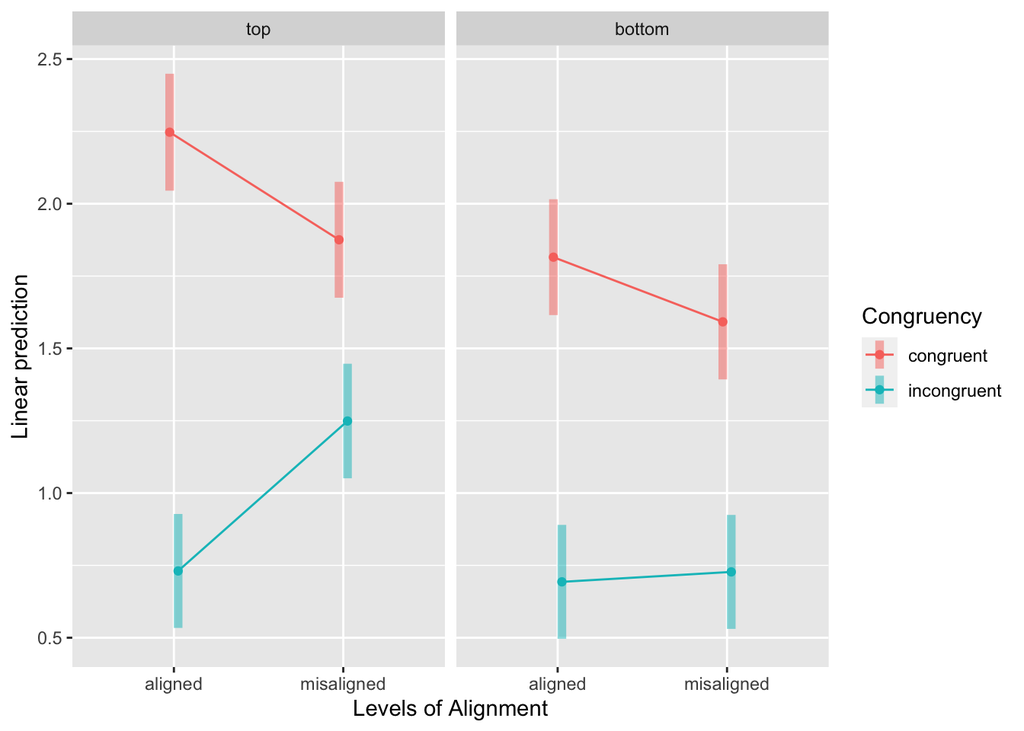

```r
emmip(emm_d, Congruency ~ Alignment | Cue, CIs = TRUE)
```

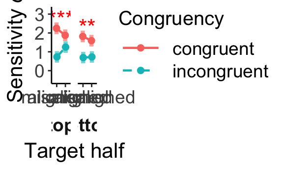

```r
plot_E12_cf_d <- summary(emm_d[1:8], infer = c(TRUE, FALSE)) %>%
  as_tibble() %>%
  ggplot(aes(y = estimate, x = Alignment, color = Congruency, group = Congruency)) +
  geom_point(position = position_dodge(width = 0.1), size = 2) +
  geom_line(aes(linetype = Congruency), position = position_dodge(width = 0.1),
            size = 0.8) +
  scale_linetype_manual(values=c("solid", "dashed"))+
  geom_errorbar(aes(ymin = asymp.LCL, ymax = asymp.UCL), size=1.5, width=0,
                alpha = .6, position = position_dodge(width = 0.1),
                show.legend = F) +
  facet_grid(. ~Cue, switch = "both") +
  coord_cartesian(ylim = ylimit_cf_d) +  # set the limit for y axis c(0, 1100)
  labs(x = "Target half", y = expression("Sensitivity"~italic("d'")), fill = "Congruency") +  # set the names for main, x and y axises
  geom_text(label = c("***", "", "", "", "**", "", "", ""), color = "red", size = 6, nudge_y = 0.5, nudge_x = 0.5) + # add starts to the significant columns
  theme_bw() +
  theme(
    text = element_text(size = 10),
    axis.title = element_text(size = 16),
    axis.text = element_text(size = 14), # the size of the texts in plot
    # axis.text.x = element_text(angle = 45, vjust = 0.5),
    legend.title=element_text(size=15),
    legend.text=element_text(size=14),
    legend.position = "right",
    legend.key.width = unit(1.2, "cm"),
    plot.title = element_text(lineheight=.8, face="bold", size = 17),
    panel.border = element_blank(),
    panel.grid.minor = element_blank(),
    panel.grid.major = element_blank(),
    axis.line.x = element_line(colour = 'black', size=0.5, linetype='solid'),
    axis.line.y = element_line(colour = 'black', size=0.5, linetype='solid'),
    # remove the facet background color
    strip.text = element_text(face="bold", size=14, lineheight=5.0),
    strip.background = element_rect(fill="white", colour="white", size=1),
    strip.placement = "outside"
  )

# ggsave(filename = "E12_cf_d.pdf", plot_E12_cf_d, width = 8, height = 4.8)
plot_E12_cf_d
```

#### 4.1.2.3 Composite effects

Composite face effects for top and bottom parts:

```r
emm_d_cf <- contrast(emm_resp, interaction = "pairwise", by = "Cue")
summary(emm_d_cf[1:2], infer = TRUE)
```

```
##  Alignment_pairwise   Congruency_pairwise     SameDifferent_pairwise Cue    estimate     SE  df asymp.LCL asymp.UCL z.ratio p.value
##  aligned - misaligned congruent - incongruent same - different       top       0.890 0.0814 Inf     0.730     1.049 10.936  <.0001
##  aligned - misaligned congruent - incongruent same - different       bottom    0.258 0.0796 Inf     0.102     0.414  3.238  0.0012
##
## Results are averaged over the levels of: Probability
## Confidence level used: 0.95
```

#### 4.1.2.4 Facilitation and interference

```r
# Sensitivity d'
emm_d_fi <- contrast(emm_resp, interaction = "pairwise", by = c("Cue", "Congruency"), adjust = "Tukey")
summary(emm_d_fi[1:4], infer=TRUE)
```

```
##  Alignment_pairwise   SameDifferent_pairwise Cue    Congruency  estimate     SE  df asymp.LCL asymp.UCL z.ratio p.value
##  aligned - misaligned same - different       top    congruent     0.3718 0.0561 Inf    0.2277    0.5158   6.631 <.0001
##  aligned - misaligned same - different       top    incongruent  -0.5182 0.0500 Inf   -0.6468   -0.3897 -10.357 <.0001
##  aligned - misaligned same - different       bottom congruent     0.2235 0.0542 Inf    0.0842    0.3628   4.122 0.0002
##  aligned - misaligned same - different       bottom incongruent  -0.0343 0.0493 Inf   -0.1611    0.0924  -0.696 0.8987
##
## Results are averaged over the levels of: Probability
## Confidence level used: 0.95
## Conf-level adjustment: tukey method for comparing a family of 4 estimates
## P value adjustment: tukey method for comparing a family of 4 estimates
```

```r
# showing the differences between aligned and misaligned (aligned-misaligned)
# emmip(emm_d_fi[1:4], ~ Cue | Congruency, CIs = TRUE, adjust = "Tukey") +
#   geom_hline(yintercept = 0, linetype = "dashed")
```

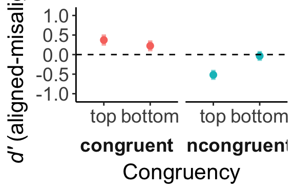

```r
plot_E12_cffi_d <- summary(emm_d_fi[1:4], infer=TRUE) %>%
  as_tibble() %>%
  ggplot(aes(y = estimate, x = Cue, color = Congruency)) +
  geom_point(size = 2) +
  geom_errorbar(aes(ymin = asymp.LCL, ymax = asymp.UCL), size=1.5, width=0,
                alpha = .6) +
  geom_hline(yintercept = 0, linetype = "dashed") +
  facet_grid(. ~ Congruency, switch = "both") +
  coord_cartesian(ylim = ylimit_cf_fi_d) +  # set the limit for y axis c(0, 1100)
  labs(x = "Congruency", y = expression(italic("d'")~"(aligned-misaligned)")) +  # set the names for main, x and y axises
  theme_bw() +
  theme(
    text = element_text(size = 10),
    axis.title = element_text(size = 16),
    axis.text = element_text(size = 14), # the size of the texts in plot
    # axis.text.x = element_text(angle = 45, vjust = 0.5),
    legend.title=element_text(size=15),
    legend.text=element_text(size=14),
    legend.position = "none",
    legend.key.width = unit(1.2, "cm"),
    plot.title = element_text(lineheight=.8, face="bold", size = 17),
    panel.border = element_blank(),
    panel.grid.minor = element_blank(),
    panel.grid.major = element_blank(),
    axis.line.x = element_line(colour = 'black', size=0.5, linetype='solid'),
    axis.line.y = element_line(colour = 'black', size=0.5, linetype='solid'),
    # remove the facet background color
    strip.text = element_text(face="bold", size=14, lineheight=5.0),
    strip.background = element_rect(fill="white", colour="white", size=1),
    strip.placement = "outside"
  ) +
  NULL

# ggsave(filename = "E12_fi_d.pdf", plot_E12_cffi_d, width = 7, height = 4.55)
plot_E12_cffi_d
```

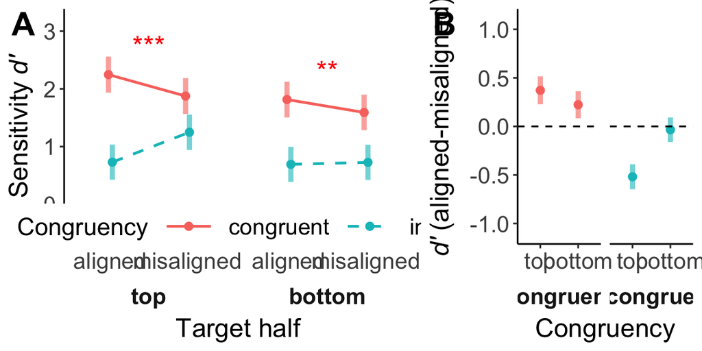

```r
plot_E12_cf_d_ <- plot_E12_cf_d +
  guides(color = guide_legend(nrow = 1, title.position = "left"),
         linetype = guide_legend(nrow = 1, title.position = "left")) +
  theme(legend.position = c(0.6, 0.075),
        legend.box = "horizontal")

plot_E12_d <- ggarrange(plot_E12_cf_d_, plot_E12_cffi_d,
                       labels = c("A", "B"),
                       font.label = (list(size = 20)),
                       widths = c(1.5, 1),
                       nrow = 1)

# ggsave(filename = "E12_d.pdf", plot_E12_d, width = 10, height = 4.5)
plot_E12_d
```

#### 4.1.2.5 Comparisons between facilitation and interference

```r
contrast(emm_d_fi, method = list("faci-inte"=c(1, 1)), by = "Cue") %>%
  summary(infer = TRUE)
```

```
## Cue = top:
##  contrast  estimate     SE  df asymp.LCL asymp.UCL z.ratio p.value
##  faci-inte   -0.146 0.0684 Inf    -0.280   -0.0125 -2.142  0.0322
##
## Cue = bottom:
##  contrast  estimate     SE  df asymp.LCL asymp.UCL z.ratio p.value
##  faci-inte    0.189 0.0664 Inf     0.059    0.3193  2.849  0.0044
##
## Results are averaged over the levels of: Probability
## Confidence level used: 0.95
```

```r
# contrast(emm_d, method = list("faci-inte"=c(1, -1, 1, -1 )), by = "Cue") %>%
#   summary(infer = TRUE)
```

```r
# emmeans(glmm_resp_opt, ~ Alignment + SameDifferent | Cue ) %>%
#   contrast(interaction = "pairwise")
```

#### 4.1.2.6 SCF analysis

```r
# Accuracy for same trials only
emm_resp_scf <- contrast(regrid(emm_resp), method = "pairwise", simple = "Alignment")
summary(emm_resp_scf[1:4], infer = TRUE)
```

```
##  contrast             Congruency  Cue    SameDifferent estimate      SE  df asymp.LCL asymp.UCL z.ratio p.value
##  aligned - misaligned congruent   top    same            0.0271 0.00964 Inf   0.00234   0.05185  2.812  0.0254
##  aligned - misaligned incongruent top    same           -0.1481 0.01574 Inf  -0.18850  -0.10762 -9.406  <.0001
##  aligned - misaligned congruent   bottom same            0.0359 0.01052 Inf   0.00888   0.06293  3.413  0.0036
##  aligned - misaligned incongruent bottom same           -0.0302 0.01557 Inf  -0.07023   0.00978 -1.941  0.2110
##
## Results are averaged over the levels of: Probability
## Confidence level used: 0.95
## Conf-level adjustment: tukey method for comparing a family of 4 estimates
## P value adjustment: tukey method for comparing a family of 4 estimates
```

```r
# Accuracy for different trials only
# emm_resp_scf[5:8]
```

```r
# false alarm
# emmip(emm_resp_scf, ~ Cue | SameDifferent + Congruency, CIs = TRUE) +
#   geom_hline(yintercept = 0, linetype = "dashed")
```

## 4.2 Response times

```r
df_lmm_rt <- df_lmm %>%
  filter(isCorrect == 1)

# save(df_lmm_rt, file = file.path("data", "df_lmm_rt.RData"))
```

### 4.2.1 Fitting the generalized mixed models

```r
# file_rt_max <- file.path(folder_lmm, "rt_lmm_max.RData")
#
# # fit the max model
# if (!file.exists(file_rt_max)) {
#   glmm_rt_max <- glmer(
#     log(RT) ~ Cue * Congruency * Alignment + Probability +
#       (Cue * Congruency * Alignment | Participant),
#     family = lognormal(),
#     data = df_lmm_rt,
#     control = glmerControl(optimizer = "optimx", # calc.derivs = FALSE,
#                            optCtrl = list(method = "nlminb", starttests = FALSE, kkt = FALSE))
#   )
#
#   save(glmm_rt_max, file = file_rt_max)
# } else {
#   load(file_rt_max)
# }
#
# print(summary(glmm_rt_max), corr = FALSE)
```

#### 4.2.1.1 The zero-correlation-parameter model

```r
file_rt_zcp <- file.path(folder_lmm, "rt_lmm_zcp.RData")

# fit the zcp1 model
if (!file.exists(file_rt_zcp)) {
  glmm_rt_zcp <- lmer(
    log(RT) ~ Cue * Congruency * Alignment + Probability +
      (Cue_C + Con_C + Ali_C +
         Cue_Con + Cue_Ali + Con_Ali +
         Cue_Con_Ali || Participant),
    data = df_lmm_rt,
    control = lmerControl(optimizer = "optimx", # calc.derivs = FALSE,
                          optCtrl = list(method = "nlminb", starttests = FALSE, kkt = FALSE))
  )
    # save(glmm_rt_zcp, file = file_rt_zcp)
} else {
    load(file_rt_zcp)
}

print(summary(glmm_rt_zcp), corr = FALSE)
```

```
## Linear mixed model fit by REML. t-tests use Satterthwaite's method ['lmerModLmerTest']
## Formula: log(RT) ~ Cue * Congruency * Alignment + Probability + (Cue_C +      Con_C + Ali_C + Cue_Con + Cue_Ali + Con_Ali + Cue_Con_Ali ||      Participant)
##    Data: df_lmm_rt
## Control: lmerControl(optimizer = "optimx", optCtrl = list(method = "nlminb",      starttests = FALSE, kkt = FALSE))
##
## REML criterion at convergence: 37568.4
##
## Scaled residuals:
##     Min      1Q  Median      3Q     Max
## -4.0118 -0.6012 -0.1452  0.4415  9.7535
##
## Random effects:
##  Groups        Name        Variance  Std.Dev.
##  Participant   (Intercept) 5.531e-02 2.352e-01
##  Participant.1 Cue_C       2.039e-02 1.428e-01
##  Participant.2 Con_C       6.458e-04 2.541e-02
##  Participant.3 Ali_C       7.453e-04 2.730e-02
##  Participant.4 Cue_Con     7.533e-04 2.745e-02
##  Participant.5 Cue_Ali     8.167e-05 9.037e-03
##  Participant.6 Con_Ali     3.866e-11 6.217e-06
##  Participant.7 Cue_Con_Ali 5.132e-03 7.164e-02
##  Residual                  1.334e-01 3.653e-01
## Number of obs: 44710, groups:  Participant, 64
##
## Fixed effects:
##                                     Estimate Std. Error         df t value Pr(>|t|)
## (Intercept)                        6.678e+00  4.171e-02  6.221e+01 160.114  < 2e-16 ***
## Cue2-1                             3.909e-02  1.830e-02  6.350e+01   2.136  0.03651 *
## Congruency2-1                      3.524e-02  4.819e-03  5.487e+01   7.314 1.17e-09 ***
## Alignment2-1                       1.469e-02  4.964e-03  5.570e+01   2.959  0.00452 **
## Probability0.5                     8.884e-02  5.897e-02  6.216e+01   1.507  0.13698
## Probability0.75                    1.024e-02  5.087e-03  4.364e+04   2.013  0.04407 *
## Cue2-1:Congruency2-1               4.223e-03  7.913e-03  5.078e+01   0.534  0.59592
## Cue2-1:Alignment2-1               -2.254e-03  7.082e-03  3.155e+01  -0.318  0.75234
## Congruency2-1:Alignment2-1        -4.508e-02  6.976e-03  3.982e+04  -6.463 1.04e-10 ***
## Cue2-1:Congruency2-1:Alignment2-1 -1.414e-02  1.681e-02  3.807e+01  -0.841  0.40551
## ---
## Signif. codes:  0 '***' 0.001 '**' 0.01 '*' 0.05 '.' 0.1 ' ' 1
## optimizer (optimx) convergence code: 0 (OK)
## boundary (singular) fit: see ?isSingular
```

#### 4.2.1.2 The reduced model

```r
summary(rePCA(glmm_rt_zcp))
```

```
## $Participant
## Importance of components:
##                          [,1]   [,2]    [,3]    [,4]    [,5]    [,6]    [,7]      [,8]
## Standard deviation     0.6438 0.3909 0.19612 0.07514 0.07474 0.06957 0.02474 1.702e-05
## Proportion of Variance 0.6660 0.2455 0.06179 0.00907 0.00897 0.00778 0.00098 0.000e+00
## Cumulative Proportion  0.6660 0.9114 0.97320 0.98227 0.99124 0.99902 1.00000 1.000e+00
```

`Con_Ali`, and `Cue_Ali` were removed from extended model (`glmm_rt_zcp`) due to that the variances they explained were smaller than 0.1%, making `glmm_rt_rdc`.

```r
file_rt_rdc <- file.path(folder_lmm, "rt_lmm_rdc.RData")

# fit the zcp model
# three random effects were removed
if (!file.exists(file_rt_rdc)) {
  glmm_rt_rdc <- lmer(
    log(RT) ~ Cue * Congruency * Alignment + Probability +
      (Cue_C + Con_C + Ali_C +
         Cue_Con +  # Con_Ali + Cue_Ali +
         Cue_Con_Ali || Participant),
    data = df_lmm_rt,
    control = lmerControl(optimizer = "optimx", # calc.derivs = FALSE,
                          optCtrl = list(method = "nlminb", starttests = FALSE, kkt = FALSE))
  )
  # save(glmm_rt_rdc, file = file_rt_rdc)
} else {
  load(file_rt_rdc)
}

print(summary(glmm_rt_rdc), corr = FALSE)
```

```
## Linear mixed model fit by REML. t-tests use Satterthwaite's method ['lmerModLmerTest']
## Formula: log(RT) ~ Cue * Congruency * Alignment + Probability + (Cue_C +      Con_C + Ali_C + Cue_Con + Cue_Con_Ali || Participant)
##    Data: df_lmm_rt
## Control: lmerControl(optimizer = "optimx", optCtrl = list(method = "nlminb",      starttests = FALSE, kkt = FALSE))
##
## REML criterion at convergence: 37568.4
##
## Scaled residuals:
##     Min      1Q  Median      3Q     Max
## -4.0114 -0.6010 -0.1454  0.4413  9.7530
##
## Random effects:
##  Groups        Name        Variance  Std.Dev.
##  Participant   (Intercept) 0.0553065 0.23517
##  Participant.1 Cue_C       0.0203864 0.14278
##  Participant.2 Con_C       0.0006454 0.02540
##  Participant.3 Ali_C       0.0007437 0.02727
##  Participant.4 Cue_Con     0.0007531 0.02744
##  Participant.5 Cue_Con_Ali 0.0051144 0.07151
##  Residual                  0.1334233 0.36527
## Number of obs: 44710, groups:  Participant, 64
##
## Fixed effects:
##                                     Estimate Std. Error         df t value Pr(>|t|)
## (Intercept)                        6.678e+00  4.171e-02  6.221e+01 160.114  < 2e-16 ***
## Cue2-1                             3.910e-02  1.830e-02  6.350e+01   2.136  0.03651 *
## Congruency2-1                      3.524e-02  4.818e-03  5.488e+01   7.315 1.16e-09 ***
## Alignment2-1                       1.468e-02  4.961e-03  5.586e+01   2.959  0.00452 **
## Probability0.5                     8.884e-02  5.897e-02  6.216e+01   1.507  0.13700
## Probability0.75                    1.024e-02  5.087e-03  4.369e+04   2.013  0.04411 *
## Cue2-1:Congruency2-1               4.227e-03  7.913e-03  5.079e+01   0.534  0.59555
## Cue2-1:Alignment2-1               -2.343e-03  6.978e-03  4.357e+04  -0.336  0.73703
## Congruency2-1:Alignment2-1        -4.510e-02  6.975e-03  4.236e+04  -6.465 1.02e-10 ***
## Cue2-1:Congruency2-1:Alignment2-1 -1.414e-02  1.680e-02  3.814e+01  -0.841  0.40538
## ---
## Signif. codes:  0 '***' 0.001 '**' 0.01 '*' 0.05 '.' 0.1 ' ' 1
```

#### 4.2.1.3 The extended model

```r
file_rt_etd <- file.path(folder_lmm, "rt_lmm_etd.RData")

# fit the etd model
if (!file.exists(file_rt_etd)) {
   glmm_rt_etd <- lmer(
    log(RT) ~ Cue * Congruency * Alignment + Probability +
      (Cue_C + Con_C + Ali_C +
         Cue_Con +  # Con_Ali + Cue_Ali +
         Cue_Con_Ali | Participant),
    data = df_lmm_rt,
    control = lmerControl(optimizer = "optimx", # calc.derivs = FALSE,
                          optCtrl = list(method = "nlminb", starttests = FALSE, kkt = FALSE))
  )
  # save(glmm_rt_etd, file = glmm_rt_etd)
} else {
  load(file_rt_etd)
}

print(summary(glmm_rt_etd), corr = FALSE)
```

```
## Linear mixed model fit by REML. t-tests use Satterthwaite's method ['lmerModLmerTest']
## Formula: log(RT) ~ Cue * Congruency * Alignment + Probability + (Cue_C +      Con_C + Ali_C + Cue_Con + Cue_Con_Ali | Participant)
##    Data: df_lmm_rt
## Control: lmerControl(optimizer = "optimx", optCtrl = list(method = "nlminb",      starttests = FALSE, kkt = FALSE))
##
## REML criterion at convergence: 37540.1
##
## Scaled residuals:
##     Min      1Q  Median      3Q     Max
## -4.0149 -0.6012 -0.1444  0.4431  9.7665
##
## Random effects:
##  Groups      Name        Variance  Std.Dev. Corr
##  Participant (Intercept) 0.0550740 0.23468
##              Cue_C       0.0203309 0.14259  -0.07
##              Con_C       0.0006861 0.02619  -0.14  0.45
##              Ali_C       0.0008223 0.02868  -0.08 -0.12  0.31
##              Cue_Con     0.0011893 0.03449   0.17  0.24  0.03 -0.72
##              Cue_Con_Ali 0.0054717 0.07397  -0.72  0.11 -0.37 -0.10 -0.37
##  Residual                0.1333885 0.36522
## Number of obs: 44710, groups:  Participant, 64
##
## Fixed effects:
##                                     Estimate Std. Error         df t value Pr(>|t|)
## (Intercept)                        6.672e+00  3.986e-02  6.803e+01 167.402  < 2e-16 ***
## Cue2-1                             3.912e-02  1.828e-02  6.342e+01   2.140  0.03618 *
## Congruency2-1                      3.621e-02  4.867e-03  5.542e+01   7.440 6.88e-10 ***
## Alignment2-1                       1.471e-02  5.075e-03  5.567e+01   2.898  0.00537 **
## Probability0.5                     1.002e-01  5.378e-02  6.300e+01   1.863  0.06707 .
## Probability0.75                    1.010e-02  5.085e-03  4.336e+04   1.986  0.04707 *
## Cue2-1:Congruency2-1               4.786e-03  8.328e-03  5.356e+01   0.575  0.56789
## Cue2-1:Alignment2-1               -2.922e-03  6.971e-03  4.343e+04  -0.419  0.67507
## Congruency2-1:Alignment2-1        -4.461e-02  6.965e-03  4.312e+04  -6.404 1.53e-10 ***
## Cue2-1:Congruency2-1:Alignment2-1 -1.339e-02  1.693e-02  5.914e+01  -0.791  0.43230
## ---
## Signif. codes:  0 '***' 0.001 '**' 0.01 '*' 0.05 '.' 0.1 ' ' 1
## optimizer (optimx) convergence code: 1
## Model failed to converge with max|grad| = 0.0169721 (tol = 0.002, component 1)
```

```r
file_rt_etd1 <- file.path(folder_lmm, "rt_lmm_etd1.RData")

# fit the etd1 model
if (!file.exists(file_rt_etd1)) {
  ss <- getME(glmm_rt_etd, c("theta","fixef"))
  glmm_rt_etd1 <- update(
    glmm_rt_etd, start=ss,
    control=lmerControl(optimizer = "optimx", # calc.derivs = FALSE,
                         optCtrl = list(method = "nlminb", starttests = FALSE, kkt = FALSE)))
} else {
  load(file_rt_etd1)
}

print(summary(glmm_rt_etd1), corr = FALSE)
```

```
## Linear mixed model fit by REML. t-tests use Satterthwaite's method ['lmerModLmerTest']
## Formula: log(RT) ~ Cue * Congruency * Alignment + Probability + (Cue_C +      Con_C + Ali_C + Cue_Con + Cue_Con_Ali | Participant)
##    Data: df_lmm_rt
## Control: lmerControl(optimizer = "optimx", optCtrl = list(method = "nlminb",      starttests = FALSE, kkt = FALSE))
##
## REML criterion at convergence: 37540.1
##
## Scaled residuals:
##     Min      1Q  Median      3Q     Max
## -4.0149 -0.6012 -0.1445  0.4431  9.7665
##
## Random effects:
##  Groups      Name        Variance  Std.Dev. Corr
##  Participant (Intercept) 0.0550740 0.23468
##              Cue_C       0.0203296 0.14258  -0.07
##              Con_C       0.0006850 0.02617  -0.14  0.45
##              Ali_C       0.0008217 0.02867  -0.08 -0.12  0.31
##              Cue_Con     0.0011887 0.03448   0.17  0.24  0.03 -0.72
##              Cue_Con_Ali 0.0054717 0.07397  -0.72  0.11 -0.37 -0.10 -0.37
##  Residual                0.1333887 0.36522
## Number of obs: 44710, groups:  Participant, 64
##
## Fixed effects:
##                                     Estimate Std. Error         df t value Pr(>|t|)
## (Intercept)                        6.672e+00  3.986e-02  6.803e+01 167.400  < 2e-16 ***
## Cue2-1                             3.912e-02  1.828e-02  6.343e+01   2.140  0.03617 *
## Congruency2-1                      3.621e-02  4.865e-03  5.547e+01   7.442 6.78e-10 ***
## Alignment2-1                       1.470e-02  5.074e-03  5.570e+01   2.898  0.00536 **
## Probability0.5                     1.002e-01  5.378e-02  6.299e+01   1.863  0.06711 .
## Probability0.75                    1.010e-02  5.085e-03  4.336e+04   1.986  0.04707 *
## Cue2-1:Congruency2-1               4.786e-03  8.327e-03  5.357e+01   0.575  0.56791
## Cue2-1:Alignment2-1               -2.922e-03  6.971e-03  4.343e+04  -0.419  0.67505
## Congruency2-1:Alignment2-1        -4.461e-02  6.965e-03  4.312e+04  -6.404 1.53e-10 ***
## Cue2-1:Congruency2-1:Alignment2-1 -1.339e-02  1.693e-02  5.914e+01  -0.791  0.43222
## ---
## Signif. codes:  0 '***' 0.001 '**' 0.01 '*' 0.05 '.' 0.1 ' ' 1
## optimizer (optimx) convergence code: 1
## Model failed to converge with max|grad| = 0.0167706 (tol = 0.002, component 1)
```

```r
summary(rePCA(glmm_rt_etd1))
```

```
## $Participant
## Importance of components:
##                          [,1]   [,2]    [,3]    [,4]    [,5]      [,6]
## Standard deviation     0.6608 0.3912 0.15145 0.11135 0.03757 0.0008193
## Proportion of Variance 0.6970 0.2443 0.03661 0.01979 0.00225 0.0000000
## Cumulative Proportion  0.6970 0.9414 0.97796 0.99775 1.00000 1.0000000
```

```r
file_rt_etd2 <- file.path(folder_lmm, "rt_lmm_etd2.RData")

# fit the etd2 model
if (!file.exists(file_rt_etd2)) {
  glmm_rt_etd2 <- lmer(
    log(RT) ~ Cue * Congruency * Alignment + Probability +
      (Cue_C + # Con_C + Ali_C +
         Cue_Con +  # Con_Ali + Cue_Ali +
         Cue_Con_Ali | Participant),
    data = df_lmm_rt,
    control = lmerControl(optimizer = "optimx", # calc.derivs = FALSE,
                          optCtrl = list(method = "nlminb", starttests = FALSE, kkt = FALSE))
  )
  # save(glmm_rt_etd2, file = file_rt_etd2)
} else {
  load(file_rt_etd2)
}

print(summary(glmm_rt_etd2), corr = FALSE)
```

```
## Linear mixed model fit by REML. t-tests use Satterthwaite's method ['lmerModLmerTest']
## Formula: log(RT) ~ Cue * Congruency * Alignment + Probability + (Cue_C +      Cue_Con + Cue_Con_Ali | Participant)
##    Data: df_lmm_rt
## Control: lmerControl(optimizer = "optimx", optCtrl = list(method = "nlminb",      starttests = FALSE, kkt = FALSE))
##
## REML criterion at convergence: 37587.3
##
## Scaled residuals:
##     Min      1Q  Median      3Q     Max
## -3.9925 -0.6004 -0.1446  0.4413  9.7582
##
## Random effects:
##  Groups      Name        Variance  Std.Dev. Corr
##  Participant (Intercept) 0.0552105 0.23497
##              Cue_C       0.0203947 0.14281  -0.07
##              Cue_Con     0.0007303 0.02702   0.14  0.27
##              Cue_Con_Ali 0.0048203 0.06943  -0.77  0.09 -0.49
##  Residual                0.1337601 0.36573
## Number of obs: 44710, groups:  Participant, 64
##
## Fixed effects:
##                                     Estimate Std. Error         df t value Pr(>|t|)
## (Intercept)                        6.674e+00  4.004e-02  6.743e+01 166.698  < 2e-16 ***
## Cue2-1                             3.916e-02  1.830e-02  6.344e+01   2.139   0.0363 *
## Congruency2-1                      3.514e-02  3.508e-03  3.876e+04  10.017  < 2e-16 ***
## Alignment2-1                       1.379e-02  3.483e-03  4.367e+04   3.961 7.48e-05 ***
## Probability0.5                     9.634e-02  5.422e-02  6.218e+01   1.777   0.0805 .
## Probability0.75                    1.030e-02  5.092e-03  4.368e+04   2.023   0.0431 *
## Cue2-1:Congruency2-1               4.982e-03  7.858e-03  4.983e+01   0.634   0.5290
## Cue2-1:Alignment2-1               -2.427e-03  6.965e-03  4.418e+04  -0.348   0.7275
## Congruency2-1:Alignment2-1        -4.614e-02  6.968e-03  4.154e+04  -6.622 3.58e-11 ***
## Cue2-1:Congruency2-1:Alignment2-1 -1.371e-02  1.663e-02  3.757e+01  -0.824   0.4149
## ---
## Signif. codes:  0 '***' 0.001 '**' 0.01 '*' 0.05 '.' 0.1 ' ' 1
```

#### 4.2.1.4 The optimal model

```r
# compare the extended and reduced model
anova(glmm_rt_etd2, glmm_rt_rdc, refit = FALSE)
```

```
## Data: df_lmm_rt
## Models:
## glmm_rt_rdc: log(RT) ~ Cue * Congruency * Alignment + Probability + (Cue_C +
## glmm_rt_rdc:     Con_C + Ali_C + Cue_Con + Cue_Con_Ali || Participant)
## glmm_rt_etd2: log(RT) ~ Cue * Congruency * Alignment + Probability + (Cue_C +
## glmm_rt_etd2:     Cue_Con + Cue_Con_Ali | Participant)
##              npar   AIC   BIC logLik deviance Chisq Df Pr(>Chisq)
## glmm_rt_rdc    17 37602 37750 -18784    37568
## glmm_rt_etd2   21 37629 37812 -18794    37587     0  4          1
```

```r
glmm_rt_opt <- glmm_rt_rdc

print(summary(glmm_rt_opt), corr = FALSE)
```

```
## Linear mixed model fit by REML. t-tests use Satterthwaite's method ['lmerModLmerTest']
## Formula: log(RT) ~ Cue * Congruency * Alignment + Probability + (Cue_C +      Con_C + Ali_C + Cue_Con + Cue_Con_Ali || Participant)
##    Data: df_lmm_rt
## Control: lmerControl(optimizer = "optimx", optCtrl = list(method = "nlminb",      starttests = FALSE, kkt = FALSE))
##
## REML criterion at convergence: 37568.4
##
## Scaled residuals:
##     Min      1Q  Median      3Q     Max
## -4.0114 -0.6010 -0.1454  0.4413  9.7530
##
## Random effects:
##  Groups        Name        Variance  Std.Dev.
##  Participant   (Intercept) 0.0553065 0.23517
##  Participant.1 Cue_C       0.0203864 0.14278
##  Participant.2 Con_C       0.0006454 0.02540
##  Participant.3 Ali_C       0.0007437 0.02727
##  Participant.4 Cue_Con     0.0007531 0.02744
##  Participant.5 Cue_Con_Ali 0.0051144 0.07151
##  Residual                  0.1334233 0.36527
## Number of obs: 44710, groups:  Participant, 64
##
## Fixed effects:
##                                     Estimate Std. Error         df t value Pr(>|t|)
## (Intercept)                        6.678e+00  4.171e-02  6.221e+01 160.114  < 2e-16 ***
## Cue2-1                             3.910e-02  1.830e-02  6.350e+01   2.136  0.03651 *
## Congruency2-1                      3.524e-02  4.818e-03  5.488e+01   7.315 1.16e-09 ***
## Alignment2-1                       1.468e-02  4.961e-03  5.586e+01   2.959  0.00452 **
## Probability0.5                     8.884e-02  5.897e-02  6.216e+01   1.507  0.13700
## Probability0.75                    1.024e-02  5.087e-03  4.369e+04   2.013  0.04411 *
## Cue2-1:Congruency2-1               4.227e-03  7.913e-03  5.079e+01   0.534  0.59555
## Cue2-1:Alignment2-1               -2.343e-03  6.978e-03  4.357e+04  -0.336  0.73703
## Congruency2-1:Alignment2-1        -4.510e-02  6.975e-03  4.236e+04  -6.465 1.02e-10 ***
## Cue2-1:Congruency2-1:Alignment2-1 -1.414e-02  1.680e-02  3.814e+01  -0.841  0.40538
## ---
## Signif. codes:  0 '***' 0.001 '**' 0.01 '*' 0.05 '.' 0.1 ' ' 1
```

### 4.2.2 Estimated marginal means

#### 4.2.2.1 Estimated marginal means for RT

```r
file_rt_emm <- file.path(folder_lmm, "rt_emm.RData")
if (!file.exists(file_rt_emm)) {
  emm_rt <- emmeans(glmm_rt_opt, ~ Cue + Congruency + Alignment)
} else {
  load(file_rt_emm)
}

summary(emm_rt, type = "response") # equivalent to regrid(emm_rt)
```

```
##  Cue    Congruency  Alignment  response   SE  df asymp.LCL asymp.UCL
##  top    congruent   aligned         778 25.5 Inf       730       830
##  bottom congruent   aligned         806 26.4 Inf       756       859
##  top    incongruent aligned         820 26.9 Inf       769       874
##  bottom incongruent aligned         859 28.2 Inf       805       916
##  top    congruent   misaligned      806 26.4 Inf       756       859
##  bottom congruent   misaligned      838 27.4 Inf       786       894
##  top    incongruent misaligned      817 26.8 Inf       767       872
##  bottom incongruent misaligned      848 27.8 Inf       795       904
##
## Results are averaged over the levels of: Probability
## Degrees-of-freedom method: asymptotic
## Confidence level used: 0.95
## Intervals are back-transformed from the log scale
```

```r
# emmip(regrid(emm_rt), Congruency ~ Alignment | Cue, CIs = TRUE)
```

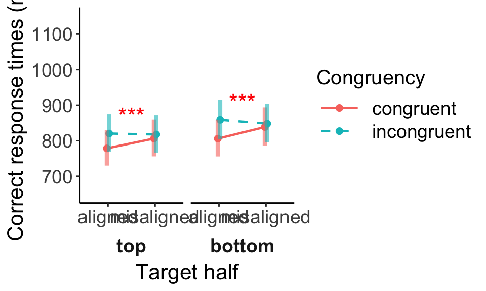

```r
plot_E12_cf_rt <- summary(emm_rt, type = "response") %>%
  as_tibble() %>%
  ggplot(aes(y = response, x = Alignment, color = Congruency, group = Congruency)) +
  geom_point(position = position_dodge(width = 0.1), size = 2) +
  geom_line(aes(linetype = Congruency), position = position_dodge(width = 0.1),
            size = 0.8) +
  scale_linetype_manual(values=c("solid", "dashed"))+
  geom_errorbar(aes(ymin = asymp.LCL, ymax = asymp.UCL), size=1.5, width=0,
                alpha = .6, position = position_dodge(width = 0.1),
                show.legend = F) +
  facet_grid(. ~Cue, switch = "both") +
  coord_cartesian(ylim = ylimit_cf_rt) +  # set the limit for y axis c(0, 1100)
  labs(x = "Target half", y = "Correct response times (ms)", fill = "Congruency") +  # set the names for main, x and y axises
  geom_text(label = c("", "", "***", "***", "", "", "", ""), color = "red", size = 6, nudge_y = 50, nudge_x = 0.5) + # add starts to the significant columns
  theme_bw() +
  theme(
    text = element_text(size = 10),
    axis.title = element_text(size = 16),
    axis.text = element_text(size = 14), # the size of the texts in plot
    # axis.text.x = element_text(angle = 45, vjust = 0.5),
    legend.title=element_text(size=15),
    legend.text=element_text(size=14),
    legend.position = "right",
    legend.key.width = unit(1.2, "cm"),
    plot.title = element_text(lineheight=.8, face="bold", size = 17),
    panel.border = element_blank(),
    panel.grid.minor = element_blank(),
    panel.grid.major = element_blank(),
    axis.line.x = element_line(colour = 'black', size=0.5, linetype='solid'),
    axis.line.y = element_line(colour = 'black', size=0.5, linetype='solid'),
    # remove the facet background color
    strip.text = element_text(face="bold", size=14, lineheight=5.0),
    strip.background = element_rect(fill="white", colour="white", size=1),
    strip.placement = "outside"
  )

# ggsave(filename = "E12_cf_rt.pdf", plot_E12_cf_rt, width = 8, height = 4.8)
plot_E12_cf_rt
```

#### 4.2.2.2 Composite effects

Composite face effects for top and bottom parts:

```r
emm_rt_cf <- contrast(regrid(emm_rt), interaction = "pairwise", by = "Cue", infer = TRUE)
emm_rt_cf[1:2]
```

```
##  Congruency_pairwise     Alignment_pairwise   Cue    estimate   SE  df asymp.LCL asymp.UCL z.ratio p.value
##  congruent - incongruent aligned - misaligned top       -30.2 8.76 Inf     -47.4     -13.0 -3.447  0.0006
##  congruent - incongruent aligned - misaligned bottom    -43.3 9.37 Inf     -61.6     -24.9 -4.616  <.0001
##
## Results are averaged over the levels of: Probability
## Confidence level used: 0.95
```

```r
# emmip(emm_rt_cf[1:2], ~ Cue , CIs = TRUE) +
#   geom_hline(yintercept = 0, linetype = "dashed")
```

#### 4.2.2.3 Facilitation and interference

```r
emm_rt_fi <- contrast(regrid(emm_rt), "pairwise", by = c("Cue", "Congruency"), infer=TRUE, adjust = "Tukey")
emm_rt_fi[1:4]
```

```
##  contrast             Cue    Congruency  estimate   SE  df asymp.LCL asymp.UCL z.ratio p.value
##  aligned - misaligned top    congruent     -27.62 6.22 Inf    -43.59     -11.6 -4.440  0.0001
##  aligned - misaligned bottom congruent     -32.54 6.59 Inf    -49.48     -15.6 -4.935  <.0001
##  aligned - misaligned top    incongruent     2.59 6.85 Inf    -15.02      20.2  0.378  0.9816
##  aligned - misaligned bottom incongruent    10.73 7.32 Inf     -8.07      29.5  1.466  0.4580
##
## Results are averaged over the levels of: Probability
## Confidence level used: 0.95
## Conf-level adjustment: tukey method for comparing a family of 4 estimates
## P value adjustment: tukey method for comparing a family of 4 estimates
```

```r
# emmip(emm_rt_fi[1:4], ~ Cue | Congruency, CIs = TRUE, adjust = "Tukey") +
#   geom_hline(yintercept = 0, linetype = "dashed")
```

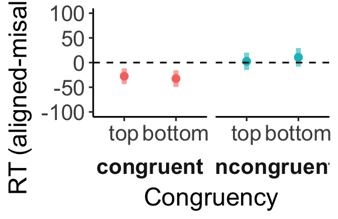

```r
plot_E12_cffi_rt <- emm_rt_fi[1:4] %>%
  as_tibble() %>%
  ggplot(aes(y = estimate, x = Cue, color = Congruency)) +
  geom_point(size = 2) +
  geom_errorbar(aes(ymin = asymp.LCL, ymax = asymp.UCL), size=1.5, width=0,
                alpha = .6) +
  geom_hline(yintercept = 0, linetype = "dashed") +
  facet_grid(. ~ Congruency, switch = "both") +
  coord_cartesian(ylim = ylimit_cf_fi_rt) +  # set the limit for y axis c(0, 1100)
  labs(x = "Congruency", y = expression(RT~"(aligned-misaligned)")) +  # set the names for main, x and y axises
  theme_bw() +
  theme(
    text = element_text(size = 10),
    axis.title = element_text(size = 16),
    axis.text = element_text(size = 14), # the size of the texts in plot
    # axis.text.x = element_text(angle = 45, vjust = 0.5),
    legend.title=element_text(size=15),
    legend.text=element_text(size=14),
    legend.position = "none",
    legend.key.width = unit(1.2, "cm"),
    plot.title = element_text(lineheight=.8, face="bold", size = 17),
    panel.border = element_blank(),
    panel.grid.minor = element_blank(),
    panel.grid.major = element_blank(),
    axis.line.x = element_line(colour = 'black', size=0.5, linetype='solid'),
    axis.line.y = element_line(colour = 'black', size=0.5, linetype='solid'),
    # remove the facet background color
    strip.text = element_text(face="bold", size=14, lineheight=5.0),
    strip.background = element_rect(fill="white", colour="white", size=1),
    strip.placement = "outside"
  ) +
  NULL

# ggsave(filename = "E12_fi_rt.pdf", plot_E12_cffi_rt, width = 7, height = 4.55)
plot_E12_cffi_rt
```

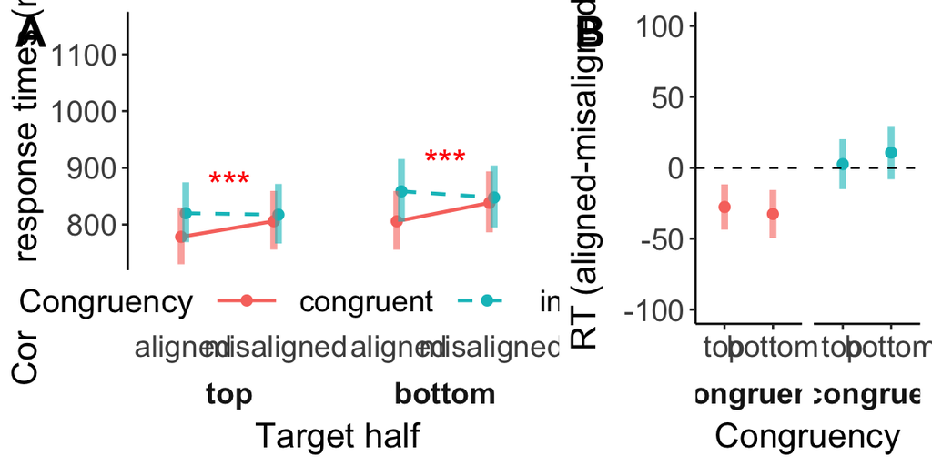

```r
plot_E12_cf_rt_ <- plot_E12_cf_rt +
  guides(color = guide_legend(nrow = 1, title.position = "left"),
         linetype = guide_legend(nrow = 1, title.position = "left")) +
  theme(legend.position = c(0.55, 0.075),
        legend.box = "horizontal")

plot_E12_rt <- ggarrange(plot_E12_cf_rt_, plot_E12_cffi_rt,
                       labels = c("A", "B"),
                       font.label = (list(size = 20)),
                       widths = c(1.5, 1),
                       nrow = 1)

# ggsave(filename = "E12_rt.pdf", plot_E12_rt, width = 10, height = 4.5)
plot_E12_rt
```

#### 4.2.2.4 Comparisons between facilitation and interference

```r
summary(contrast(emm_rt_fi, method = list("faci-inte"=c(1, 1)), by = "Cue"), infer = TRUE)
```

```
## Cue = top:
##  contrast  estimate    SE  df asymp.LCL asymp.UCL z.ratio p.value
##  faci-inte    -25.0  9.72 Inf     -44.1     -5.97 -2.574  0.0100
##
## Cue = bottom:
##  contrast  estimate    SE  df asymp.LCL asymp.UCL z.ratio p.value
##  faci-inte    -21.8 10.30 Inf     -42.0     -1.62 -2.118  0.0342
##
## Results are averaged over the levels of: Probability
## Confidence level used: 0.95
```

```r
emmeans(regrid(emm_rt), ~ Alignment | Cue) %>%
  # regrid() %>%
  contrast(interaction = "pairwise") %>%
  summary(infer = TRUE)
```

```
## Cue = top:
##  Alignment_pairwise   estimate   SE  df asymp.LCL asymp.UCL z.ratio p.value
##  aligned - misaligned    -12.5 4.86 Inf       -22    -2.986 -2.574  0.0100
##
## Cue = bottom:
##  Alignment_pairwise   estimate   SE  df asymp.LCL asymp.UCL z.ratio p.value
##  aligned - misaligned    -10.9 5.15 Inf       -21    -0.812 -2.118  0.0342
##
## Results are averaged over the levels of: Probability, Congruency
## Confidence level used: 0.95
```

## 4.3 Response times with same trials only

```r
df_lmm_rt_scf <- df_lmm_rt %>%
  filter(SameDifferent == "same",
         Congruency == "incongruent")

# save(df_lmm_rt_scf, file = file.path("data", "df_lmm_rt_scf.RData"))
```

### 4.3.1 Fitting the generalized mixed models

```r
# file_rt_scf_max <- file.path(folder_lmm, "rt_scf_lmm_max.RData")
#
# # fit the max model
# if (!file.exists(file_rt_scf_max)) {
#   glmm_rt_scf_max <- glmer(
#     log(RT) ~ Cue * Alignment + Probability +
#       (Cue * Alignment | Participant),
#     family = lognormal(),
#     data = df_lmm_rt_scf,
#     control = glmerControl(optimizer = "optimx", # calc.derivs = FALSE,
#                            optCtrl = list(method = "nlminb", starttests = FALSE, kkt = FALSE))
#   )
#
#   save(glmm_rt_scf_max, file = file_rt_scf_max)
# } else {
#   load(file_rt_scf_max)
# }
#
# print(summary(glmm_rt_scf_max), corr = FALSE)
```

#### 4.3.1.1 The zero-correlation-parameter model

```r
file_rt_scf_zcp <- file.path(folder_lmm, "rt_scf_lmm_zcp.RData")

# fit the zcp1 model
if (!file.exists(file_rt_scf_zcp)) {
  glmm_rt_scf_zcp <- lmer(
    log(RT) ~ Cue * Alignment + Probability +
      (Cue_C + Ali_C +
         Cue_Ali || Participant),
    data = df_lmm_rt_scf,
    control = lmerControl(optimizer = "optimx", # calc.derivs = FALSE,
                          optCtrl = list(method = "nlminb", starttests = FALSE, kkt = FALSE))
  )
    # save(glmm_rt_scf_zcp, file = file_rt_scf_zcp)
} else {
    load(file_rt_scf_zcp)
}

print(summary(glmm_rt_scf_zcp), corr = FALSE)
```

```
## Linear mixed model fit by REML. t-tests use Satterthwaite's method ['lmerModLmerTest']
## Formula: log(RT) ~ Cue * Alignment + Probability + (Cue_C + Ali_C + Cue_Ali ||      Participant)
##    Data: df_lmm_rt_scf
## Control: lmerControl(optimizer = "optimx", optCtrl = list(method = "nlminb",      starttests = FALSE, kkt = FALSE))
##
## REML criterion at convergence: 9508.8
##
## Scaled residuals:
##     Min      1Q  Median      3Q     Max
## -3.7675 -0.6052 -0.1304  0.4776  9.5685
##
## Random effects:
##  Groups        Name        Variance  Std.Dev.
##  Participant   (Intercept) 0.0564348 0.23756
##  Participant.1 Cue_C       0.0250238 0.15819
##  Participant.2 Ali_C       0.0008059 0.02839
##  Participant.3 Cue_Ali     0.0120201 0.10964
##  Residual                  0.1384638 0.37211
## Number of obs: 10496, groups:  Participant, 64
##
## Fixed effects:
##                       Estimate Std. Error         df t value Pr(>|t|)
## (Intercept)            6.67943    0.04263   62.81933 156.686   <2e-16 ***
## Cue2-1                 0.05056    0.02175   67.99058   2.325   0.0231 *
## Alignment2-1          -0.01915    0.00831   55.58099  -2.305   0.0249 *
## Probability0.5         0.08518    0.06023   62.59477   1.414   0.1623
## Probability0.75        0.02784    0.01108 9680.48405   2.513   0.0120 *
## Cue2-1:Alignment2-1   -0.01196    0.02053   42.18882  -0.583   0.5632
## ---
## Signif. codes:  0 '***' 0.001 '**' 0.01 '*' 0.05 '.' 0.1 ' ' 1
```

#### 4.3.1.2 The reduced model

```r
summary(rePCA(glmm_rt_scf_zcp))
```

```
## $Participant
## Importance of components:
##                          [,1]   [,2]   [,3]    [,4]
## Standard deviation     0.6384 0.4251 0.2946 0.07629
## Proportion of Variance 0.5986 0.2654 0.1275 0.00855
## Cumulative Proportion  0.5986 0.8640 0.9915 1.00000
```

```r
file_rt_scf_rdc <- file.path(folder_lmm, "rt_scf_lmm_rdc.RData")

# fit the rdc model
if (!file.exists(file_rt_scf_rdc)) {
  glmm_rt_scf_rdc <- lmer(
    log(RT) ~ Cue * Alignment + Probability +
      (Cue_C + # Ali_C +
         Cue_Ali || Participant),
    data = df_lmm_rt_scf,
    control = lmerControl(optimizer = "optimx", # calc.derivs = FALSE,
                          optCtrl = list(method = "nlminb", starttests = FALSE, kkt = FALSE))
  )
    # save(glmm_rt_scf_rdc, file = file_rt_scf_rdc)
} else {
    load(file_rt_scf_rdc)
}

print(summary(glmm_rt_scf_rdc), corr = FALSE)
```

```
## Linear mixed model fit by REML. t-tests use Satterthwaite's method ['lmerModLmerTest']
## Formula: log(RT) ~ Cue * Alignment + Probability + (Cue_C + Cue_Ali ||      Participant)
##    Data: df_lmm_rt_scf
## Control: lmerControl(optimizer = "optimx", optCtrl = list(method = "nlminb",      starttests = FALSE, kkt = FALSE))
##
## REML criterion at convergence: 9510.4
##
## Scaled residuals:
##     Min      1Q  Median      3Q     Max
## -3.7874 -0.6017 -0.1300  0.4826  9.5778
##
## Random effects:
##  Groups        Name        Variance Std.Dev.
##  Participant   (Intercept) 0.05643  0.2375
##  Participant.1 Cue_C       0.02498  0.1581
##  Participant.2 Cue_Ali     0.01244  0.1116
##  Residual                  0.13865  0.3724
## Number of obs: 10496, groups:  Participant, 64
##
## Fixed effects:
##                       Estimate Std. Error         df t value Pr(>|t|)
## (Intercept)          6.679e+00  4.263e-02  6.283e+01 156.691  < 2e-16 ***
## Cue2-1               5.053e-02  2.173e-02  6.802e+01   2.325  0.02305 *
## Alignment2-1        -2.058e-02  7.391e-03  9.581e+03  -2.784  0.00538 **
## Probability0.5       8.541e-02  6.023e-02  6.260e+01   1.418  0.16114
## Probability0.75      2.796e-02  1.108e-02  9.696e+03   2.523  0.01166 *
## Cue2-1:Alignment2-1 -1.269e-02  2.066e-02  4.289e+01  -0.614  0.54231
## ---
## Signif. codes:  0 '***' 0.001 '**' 0.01 '*' 0.05 '.' 0.1 ' ' 1
```

#### 4.3.1.3 The extended model

```r
file_rt_scf_etd <- file.path(folder_lmm, "rt_scf_lmm_etd.RData")

# fit the etd model
if (!file.exists(file_rt_scf_etd)) {
  glmm_rt_scf_etd <- lmer(
    log(RT) ~ Cue * Alignment + Probability +
      (Cue_C + # Ali_C +
         Cue_Ali | Participant),
    data = df_lmm_rt_scf,
    control = lmerControl(optimizer = "optimx", # calc.derivs = FALSE,
                          optCtrl = list(method = "nlminb", starttests = FALSE, kkt = FALSE))
  )
    # save(glmm_rt_scf_etd, file = file_rt_scf_etd)
} else {
    load(file_rt_scf_etd)
}

print(summary(glmm_rt_scf_etd), corr = FALSE)
```

```
## Linear mixed model fit by REML. t-tests use Satterthwaite's method ['lmerModLmerTest']
## Formula: log(RT) ~ Cue * Alignment + Probability + (Cue_C + Cue_Ali |      Participant)
##    Data: df_lmm_rt_scf
## Control: lmerControl(optimizer = "optimx", optCtrl = list(method = "nlminb",      starttests = FALSE, kkt = FALSE))
##
## REML criterion at convergence: 23073.6
##
## Scaled residuals:
##      Min       1Q   Median       3Q      Max
## -10.7153  -0.3952  -0.0443   0.3895   6.1271
##
## Random effects:
##  Groups      Name        Variance Std.Dev. Corr
##  Participant (Intercept) 0.18262  0.4273
##              Cue_C       0.06112  0.2472    0.13
##              Cue_Ali     0.08224  0.2868   -0.77 -0.25
##  Residual                0.50696  0.7120
## Number of obs: 10496, groups:  Participant, 64
##
## Fixed effects:
##                       Estimate Std. Error         df t value Pr(>|t|)
## (Intercept)            6.25985    0.07018   75.26054  89.202   <2e-16 ***
## Cue2-1                 0.05653    0.03535   69.05639   1.599   0.1143
## Alignment2-1          -0.02484    0.01410 9342.14105  -1.761   0.0783 .
## Probability0.5         0.18251    0.08883   64.74979   2.055   0.0440 *
## Probability0.75        0.04286    0.02107 8882.79629   2.035   0.0419 *
## Cue2-1:Alignment2-1    0.01540    0.04636   43.91285   0.332   0.7413
## ---
## Signif. codes:  0 '***' 0.001 '**' 0.01 '*' 0.05 '.' 0.1 ' ' 1
```

```r
# save(glmm_rt_scf_etd, file = file.path("lmm_output", "rt_scf_lmm_etd.RData"))
```

#### 4.3.1.4 The optimal model

```r
# compare the extended and reduced model
anova(glmm_rt_scf_etd, glmm_rt_scf_rdc, refit = FALSE)
```

```
## Data: df_lmm_rt_scf
## Models:
## glmm_rt_scf_rdc: log(RT) ~ Cue * Alignment + Probability + (Cue_C + Cue_Ali ||
## glmm_rt_scf_rdc:     Participant)
## glmm_rt_scf_etd: log(RT) ~ Cue * Alignment + Probability + (Cue_C + Cue_Ali |
## glmm_rt_scf_etd:     Participant)
##                 npar     AIC   BIC   logLik deviance Chisq Df Pr(>Chisq)
## glmm_rt_scf_rdc   10  9530.4  9603  -4755.2   9510.4
## glmm_rt_scf_etd   13 23099.6 23194 -11536.8  23073.6     0  3          1
```

```r
glmm_rt_scf_opt <- glmm_rt_scf_etd

print(summary(glmm_rt_scf_opt), corr = FALSE)
```

```
## Linear mixed model fit by REML. t-tests use Satterthwaite's method ['lmerModLmerTest']
## Formula: log(RT) ~ Cue * Alignment + Probability + (Cue_C + Cue_Ali |      Participant)
##    Data: df_lmm_rt_scf
## Control: lmerControl(optimizer = "optimx", optCtrl = list(method = "nlminb",      starttests = FALSE, kkt = FALSE))
##
## REML criterion at convergence: 23073.6
##
## Scaled residuals:
##      Min       1Q   Median       3Q      Max
## -10.7153  -0.3952  -0.0443   0.3895   6.1271
##
## Random effects:
##  Groups      Name        Variance Std.Dev. Corr
##  Participant (Intercept) 0.18262  0.4273
##              Cue_C       0.06112  0.2472    0.13
##              Cue_Ali     0.08224  0.2868   -0.77 -0.25
##  Residual                0.50696  0.7120
## Number of obs: 10496, groups:  Participant, 64
##
## Fixed effects:
##                       Estimate Std. Error         df t value Pr(>|t|)
## (Intercept)            6.25985    0.07018   75.26054  89.202   <2e-16 ***
## Cue2-1                 0.05653    0.03535   69.05639   1.599   0.1143
## Alignment2-1          -0.02484    0.01410 9342.14105  -1.761   0.0783 .
## Probability0.5         0.18251    0.08883   64.74979   2.055   0.0440 *
## Probability0.75        0.04286    0.02107 8882.79629   2.035   0.0419 *
## Cue2-1:Alignment2-1    0.01540    0.04636   43.91285   0.332   0.7413
## ---
## Signif. codes:  0 '***' 0.001 '**' 0.01 '*' 0.05 '.' 0.1 ' ' 1
```

### 4.3.2 Estimated marginal means

```r
file_rt_scf_emm <- file.path(folder_lmm, "rt_scf_emm.RData")
if (!file.exists(file_rt_scf_emm)) {
  emm_rt_scf <- emmeans(glmm_rt_scf_opt, ~ Cue + Alignment, pbkrtest.limit = 10500)
  save(emm_rt_scf)
} else {
  load(file_rt_scf_emm)
}

summary(emm_rt_scf, type = "response")
```

```
##  Cue    Alignment  response   SE  df asymp.LCL asymp.UCL
##  top    aligned         557 29.0 Inf       503       617
##  bottom aligned         585 40.0 Inf       512       669
##  top    misaligned      539 34.5 Inf       476       611
##  bottom misaligned      575 31.4 Inf       517       640
##
## Results are averaged over the levels of: Probability
## Degrees-of-freedom method: asymptotic
## Confidence level used: 0.95
## Intervals are back-transformed from the log scale
```

```r
# emmip(emm_rt_scf, ~ Alignment | Cue, CIs = TRUE)
```

#### 4.3.2.1 Composite effects

Composite face effects for top and bottom parts:

```r
emm_rt_scf_cf <- contrast(regrid(emm_rt_scf), "pairwise", by = "Cue", infer = TRUE)
emm_rt_scf_cf[1:2]
```

```
##  contrast             Cue    estimate   SE  df asymp.LCL asymp.UCL z.ratio p.value
##  aligned - misaligned top       17.84 14.4 Inf     -10.5      46.2 1.235   0.2169
##  aligned - misaligned bottom     9.94 16.1 Inf     -21.6      41.4 0.618   0.5363
##
## Results are averaged over the levels of: Probability
## Confidence level used: 0.95
```

```r
# emmip(emm_rt_scf_cf, ~ Cue, CIs = TRUE) +
#   geom_hline(yintercept = 0, linetype = "dashed")
```

# 5 Plots for publication

## 5.1 Experiment 1

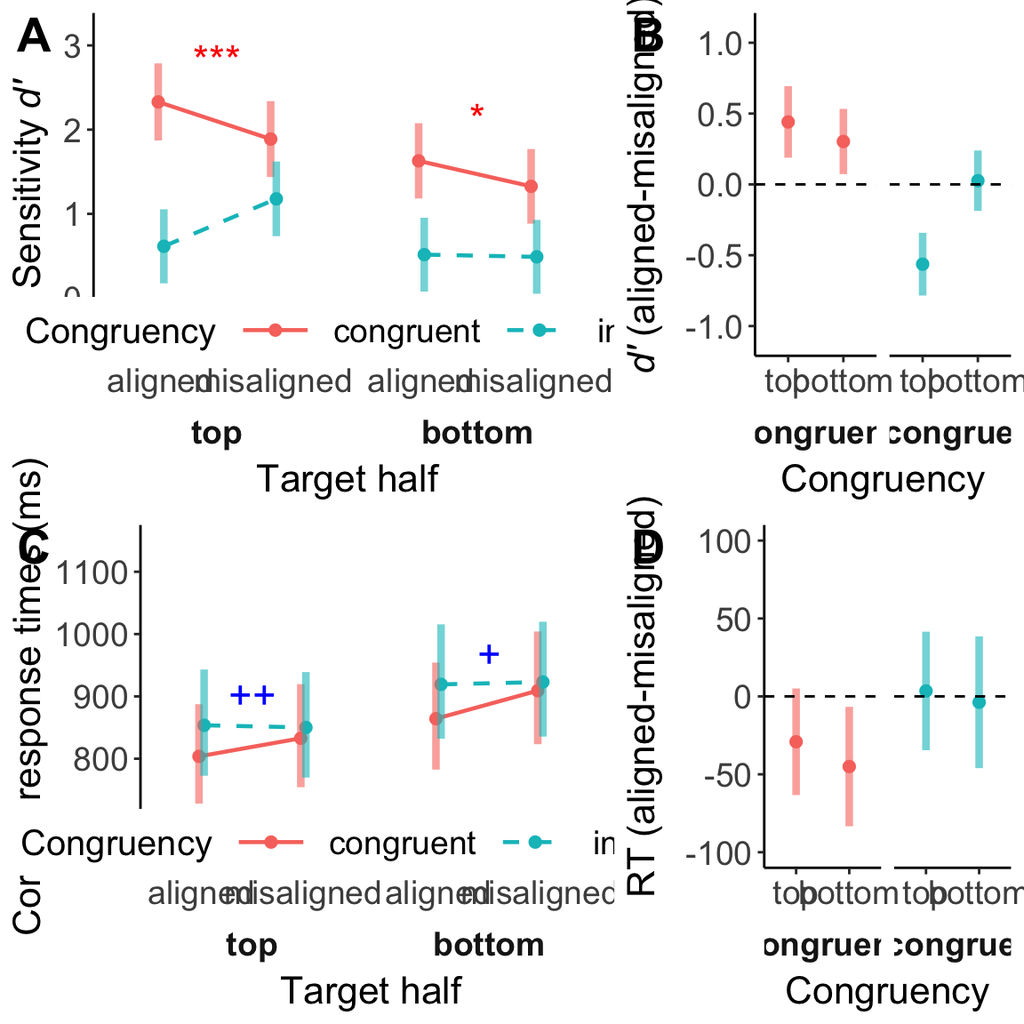

```r
plot_E1 <- ggarrange(plot_E1_cf_d_, plot_E1_cffi_d,
                     plot_E1_cf_rt_, plot_E1_cffi_rt,
                     labels = c("A", "B", "C", "D"),
                     font.label = (list(size = 20)),
                     widths = c(1.5, 1),
                     nrow = 2, ncol = 2)
# ggsave(filename = "E1.png", plot_E1, width = 10, height = 9)
plot_E1
```

## 5.2 Experiment 2

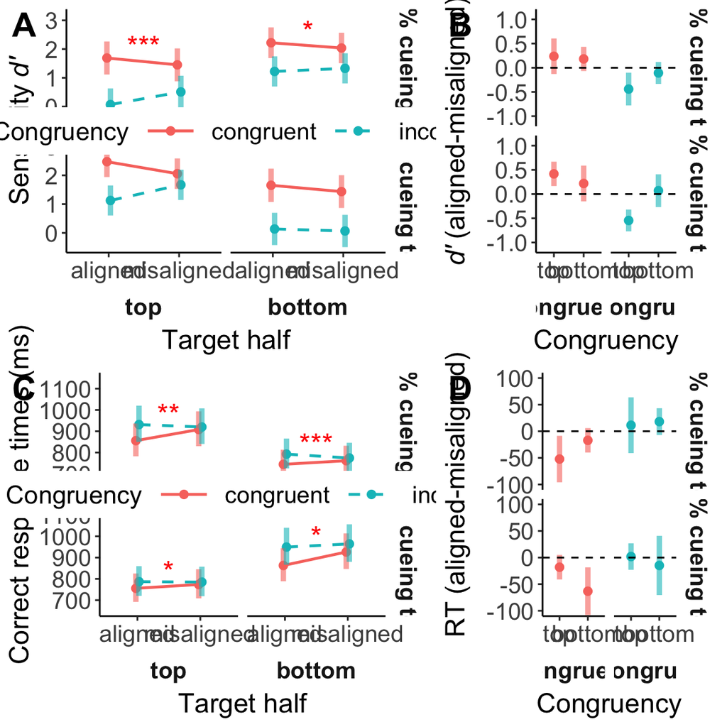

```r
plot_E2 <- ggarrange(plot_E2_cf_d_, plot_E2_cffi_d,
                     plot_E2_cf_rt_, plot_E2_cffi_rt,
                     labels = c("A", "B", "C", "D"),
                     font.label = (list(size = 20)),
                     widths = c(1.5, 1),
                     nrow = 2, ncol = 2)
# ggsave(filename = "E2.png", plot_E2, width = 10, height = 14)
plot_E2
```

## 5.3 Experiment 1&2

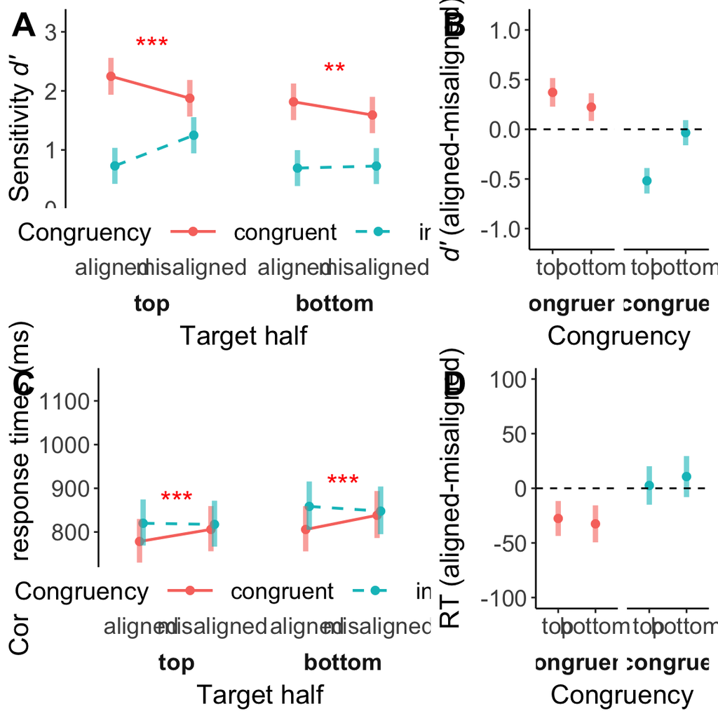

```r
plot_E12 <- ggarrange(plot_E12_cf_d_, plot_E12_cffi_d,
                     plot_E12_cf_rt_, plot_E12_cffi_rt,
                     labels = c("A", "B", "C", "D"),
                     font.label = (list(size = 20)),
                     widths = c(1.5, 1),
                     nrow = 2, ncol = 2)
# ggsave(filename = "E12.png", plot_E12, width = 10, height = 9)
plot_E12
```